# Go Big or Go Home: An Analysis of Diet & Fin Effects on Marine Fish Lengths

Haley Weinstein

June 10, 2023

## Abstract

A dataset of marine fish attributes includes the diets, caudal fin aspect ratios, and maximum lengths of over 250 different species from the North Atlantic and the North Pacific oceans. Analyzing these characteristics to observe how the physiology of a fish, as well as the diet of a fish, impacts its maximum length can inform future studies of marine fish species. Using an ANOVA test the mean lengths of fish species were compared for different feeding mode groups to see if a particular group was significantly different in length than the others. According to this test, piscivorous (fish-eating) species are longer on average than other species. Correlation and linear regression analyses of maximum lengths against caudal fin aspect ratios reveals that there is a positive correlation between length and fin size.

## Introduction

This dataset, compiled by marine biologist Esther Beukhof, is a collection of ecological traits for 6216 different marine fish taxa, including 1702 unique species, 801 genera, and 236 families along with their geographic information. This dataset aims to identify area-specific traits that can account for intraspecific trait variations in fish. Species were identified based off of international scientific bottom-trawl surveys conducted in the Northeast and Northwest Atlantic, as well as the Northeast Pacific (Beukhof). Most trait information was sourced from FishBase, a database of fish species information (Froese), and other values were collected from existing primary literature. For each species, 14 traits were identified, including several different measures of fish-size, trophic levels, lifespans, growth rates, reproductive rates, offspring size, diets, body-shapes, and habitats.  
In this analysis, I focused on the maximum length of species as the outcome of interest. The inputs of interest are the species’ feeding mode and their caudal fin aspect ratio (AR). Feeding mode is the type of food consumed, categorized into different diets including herbivorous, benthivorous, planktivorous, piscivorous, or generalist. The caudal fin aspect ratio (AR) refers to the squared height of the caudal fin divided by the surface area of the caudal fin. This is an important measure because it correlates to swimming speed, activity, metabolism, and food consumption (Beukhof). This data analysis will determine if feeding mode or AR has a significant impact on a fish species’ length. To simplify this dataset, I will be analyzing 250 randomly selected species of fish and their above traits.  
This analysis will provide an ecological and morphological context to fish sizes, which informs future research on marine fish and how their lifestyle and features impacts their physiology. I aim to investigate whether there is difference in marine fish length across different feeding styles, and to investigate if a fish’s length can be predicted by it’s fin aspect ratio.  
I hypothesize that the length of marine fish is not equal for different feeding modes. I also hypothesize that caudal fin aspect ratio does not predict the length of a marine fish.

## Exploratory Data Analysis

```
## [1]  60 116
```

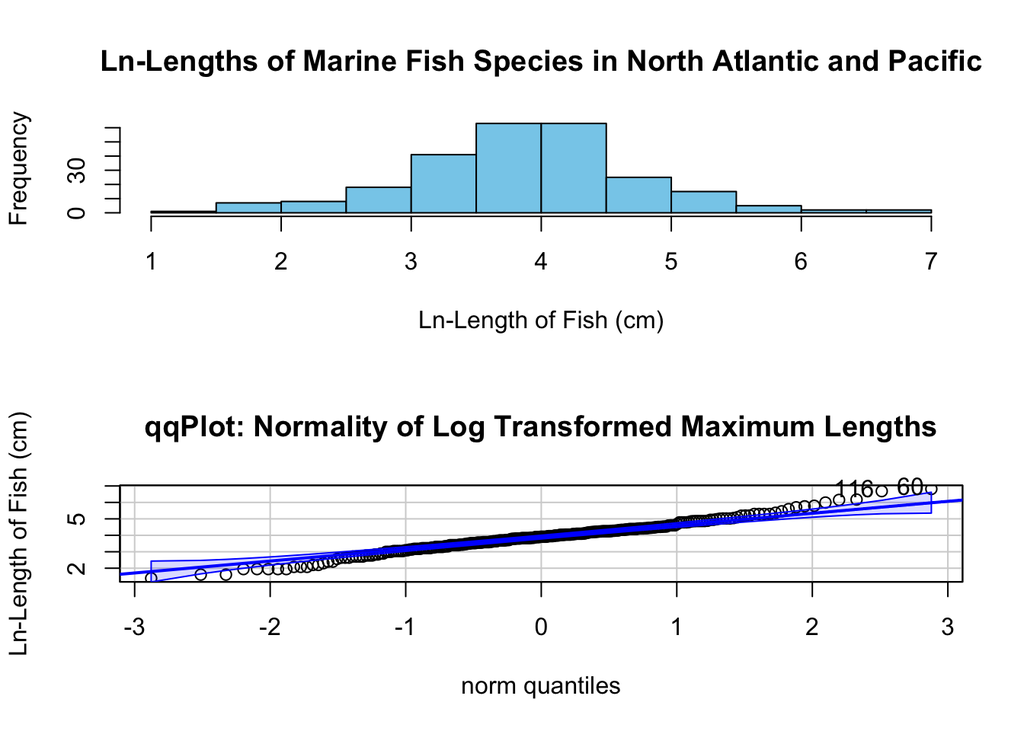

Fig. 1: The maximum lengths (in cm) of marine fish species are normally distributed after undergoing a log-transformation. This histogram provides observable evidence of normality. Analysis of a qqPlot confirms that the log-transformed length data is normally distributed, since most values do not stray from the normal region, highlighted in blue. However, there are some outliers toward the larger end of the dataset.

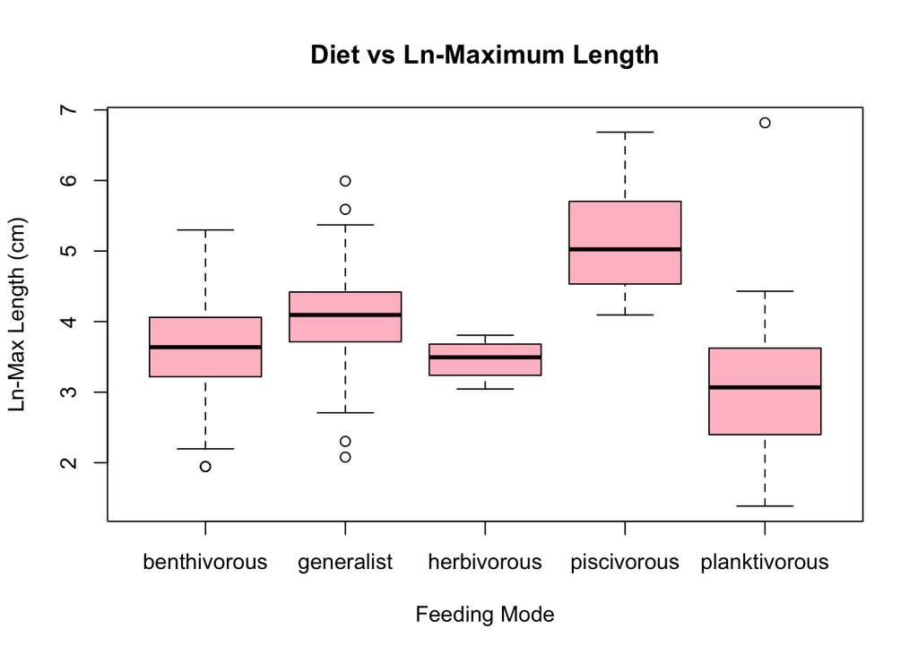

Fig. 2: This boxplot sorts the log-transformed maximum length data by feeding mode (AKA diet). Average lengths of fish vary between different feeding mode groups, with piscivorous diets having the longest fish, on average, and the planktivorous group having the shortest fish on average. There are several outliers in the generalist group, likely because generalist is a broad classification.

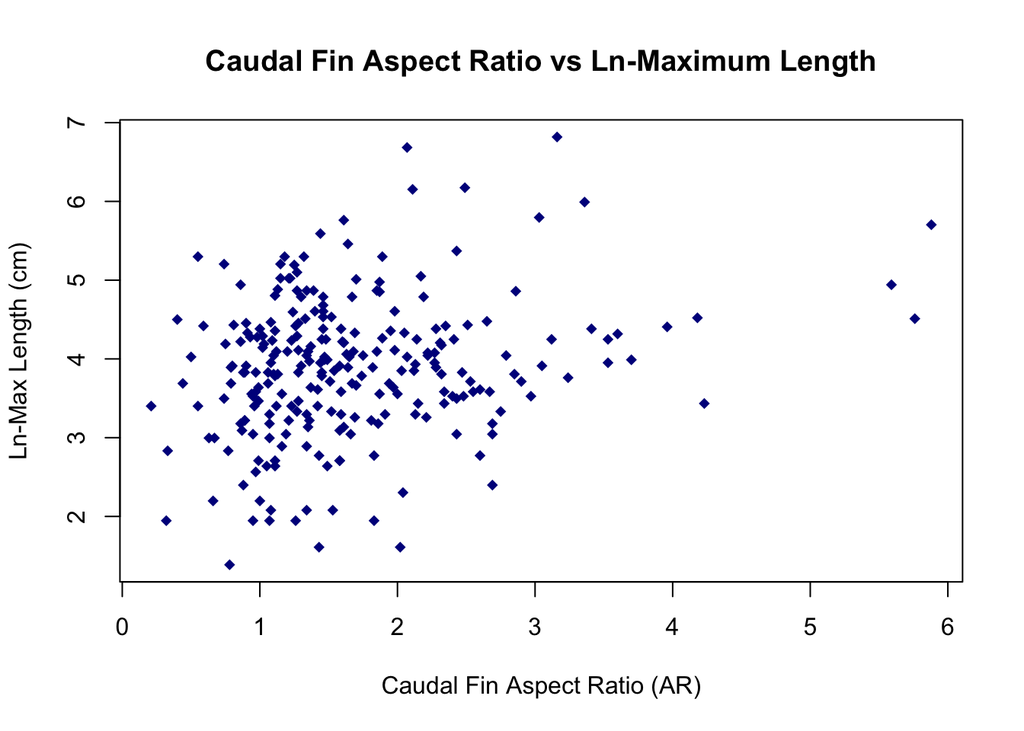

Fig. 3: This scatterplot shows the relationship between Ln-max lengths and caudal fin aspect ratios in marine fish. From a visual analysis of this scatterplot, there does not appear to be a strong correlation between these measurements, though fish with larger lengths appear to be more likely to also have large caudal fin aspect ratios.